# Stat 542: QDA, LDA, and FDA

Fall 2021

```r
library(MASS)
#help(lda)
#help(qda)
```

## MNIST Data

40 samples from each class, totally 400 training data and 400 test data. Each observation is a 16-by-16 images containing 256 measurements.

```r
load('digits.Rdata')
```

```r
dim(X)
dim(Xtest)
table(Y)
table(Ytest)
```

[output not shown]

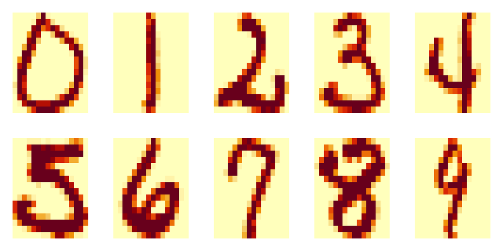

```r
par(mfrow=c(2,5), mai = c(0.2, 0.2, 0.2, 0.2))
for(i in 0:9){
  x = matrix(X[40*i+1,], 16, 16)
  image(x[,16:1], axes=FALSE)
}
```

## LDA

```r
dig.lda = lda(X,Y);
Ytest.pred = predict(dig.lda, Xtest)$class
table(Ytest, Ytest.pred)
```

```
     Ytest.pred
Ytest  0  1  2  3  4  5  6  7  8  9
    0 29  0  3  2  0  3  0  1  2  0
    1  0 40  0  0  0  0  0  0  0  0
    2  0  2 22  5  1  0  4  1  4  1
    3  0  0  1 32  0  4  1  2  0  0
    4  1  3  2  1 21  0  1  2  3  6
    5  1  0  4  3  2 23  2  0  3  2
    6  2  1  0  1  1  0 33  1  1  0
    7  1  0  1  1  1  0  1 33  0  2
    8  1  1  4  4  1  1  0  2 25  1
    9  0  0  0  1  2  0  0  0  0 37
```

```r
sum(Ytest != Ytest.pred)
```

```
[1] 105
```

## QDA

Error message: the covariance matrix is not invertable. The MASS package does not provide any solution for non-invertable covariance matrices for LDA or QDA.

```r
dig.qda = qda(X,Y) # error message
```

## FDA

The FDA direction is returned by the `lda` function. Use the directions to project both the training and test data to a lower dimensional space.

> Caution: it is meaningless to show that classes are well-seperated on the training data (same as showing training error is small); we need to check seperation on the test data.

```r
FDA.dir = dig.lda$scaling
dim(FDA.dir)  # at most 10-1 = 9 directions
```

```
[1] 256   9
```

```r
F = X%*%FDA.dir
par(mfrow=c(1,2))
plot(F[,1],F[,2], type="n", xlab="", ylab="")
text(F[,1], F[,2], Y, col=Y+1)
```

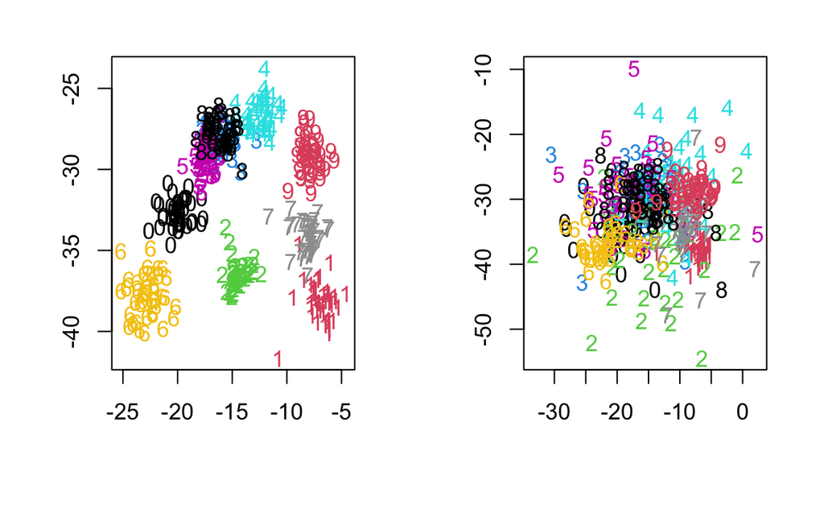

```r
Ftest = Xtest%*%dig.lda$scaling;
plot(Ftest[,1], Ftest[,2], type="n", xlab="", ylab="")
text(Ftest[,1], Ftest[,2], Ytest, col=Ytest+1)
```

You can plot the projections on other directions. None of them produces meaningful results on the test data, although the training data are well separated through those projections.

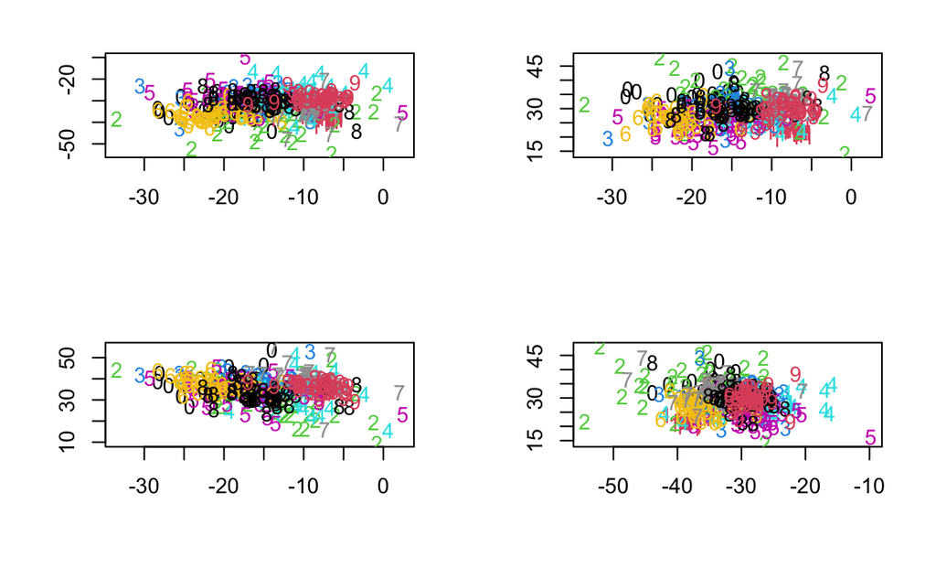

```r
xid = c(1,1,1,2); yid = c(2,3,4,3);
par(mfrow=c(2,2))
for(i in 1:4){
  plot(Ftest[,xid[i]], Ftest[,yid[i]], type="n", xlab="", ylab="");
  text(Ftest[,xid[i]], Ftest[,yid[i]], Ytest, col=Ytest+1);
}
```

### Computation Details

Check the calculation for FDA

- Compute W (within group covariance matrix)

```r
tmp.lm = lm(X ~ as.factor(Y) - 1); # each x_i - its group mean
W = cov(tmp.lm$res)
eigenW = eigen(W)
summary(eigenW)
```

```
        Length Class  Mode
values    256  -none- numeric
vectors 65536  -none- numeric
```

```r
A = eigenW$ve %*% diag(1/sqrt(eigenW$va)) %*% t(eigenW$ve)
```

- Compute B (between-group covariance matrix)

```r
B = cov(tmp.lm$fitted)
```

- Extract FDA directions. You’ll find that only the first 9 eigenvalues are non-zero.

```r
tmp.eigen = eigen(A %*% B %*% t(A))
#round(tmp.eigen$va, dig=5)
tmp = A %*% tmp.eigen$ve[, 1:9]
```

The 9 directions computed by us, stored in `tmp`, are essentially the same as the ones returned by `lda` up to some scale change.

```r
for(j in 1:9)
  print(cor(tmp[, j], FDA.dir[, j]))
```

[output not shown]

### FDA vs PCA

Obtain top 100 PCs

```r
Sigma = cov(X)
dig.eigen=eigen(Sigma);
PCA.dir = dig.eigen$ve[, 1:100]  # pick top 100 PCA directions
dim(PCA.dir)
```

[output not shown]

Note that directions from PCA are orthogonal, but directions from FDA are not. FDA directions are orthogonal with respect to the within-class covariance matrix `W`.

```r
round(t(FDA.dir) %*% FDA.dir, dig=5)
round(t(PCA.dir[, 1:10]) %*% PCA.dir[, 1:10], dig=5)
round(t(FDA.dir) %*% W %*% FDA.dir, dig=5)
```

[output not shown]

### FDA after PCA

For MNIST data, PCs form a better representation of the 16-by-16 images, instead of the original 256 pixel values. Next we try the following: use PCA to reduce the dimension of the MNIST data from 256 to 100, and then apply LDA. What’s the classification accuracy?

```r
newX = X %*% PCA.dir[, 1:100];
newdig.lda = lda(newX, Y);
newXtest = Xtest %*% PCA.dir[, 1:100]
Ytest.pred = predict(newdig.lda, newXtest)$class
table(Ytest, Ytest.pred)
```

```
     Ytest.pred
Ytest  0  1  2  3  4  5  6  7  8  9
    0 39  0  0  1  0  0  0  0  0  0
    1  0 40  0  0  0  0  0  0  0  0
    2  1  0 33  2  1  2  0  0  1  0
    3  0  0  0 35  0  1  0  3  1  0
    4  0  3  2  0 31  0  1  0  0  3
    5  2  0  2  4  0 29  0  0  2  1
    6  0  0  2  0  1  0 35  0  2  0
    7  0  0  0  0  3  0  0 35  0  2
    8  0  0  0  2  1  2  0  0 34  1
    9  0  0  0  1  0  0  0  1  0 38
```

```r
sum(Ytest != Ytest.pred)
```

```
[1] 51
```

Even the projects on the FDA directions look better if we pre-cut the dimension from 256 to the first 100 PCs.

```r
newF=newX%*%newdig.lda$scaling;
newFtest=Xtest%*%dig.eigen$ve[,1:100]%*%newdig.lda$scaling

par(mfrow=c(1,2))
plot(newF[,1],newF[,2], type="n", xlab="", ylab="")
text(newF[,1], newF[,2], Y, col= Y+1)
```

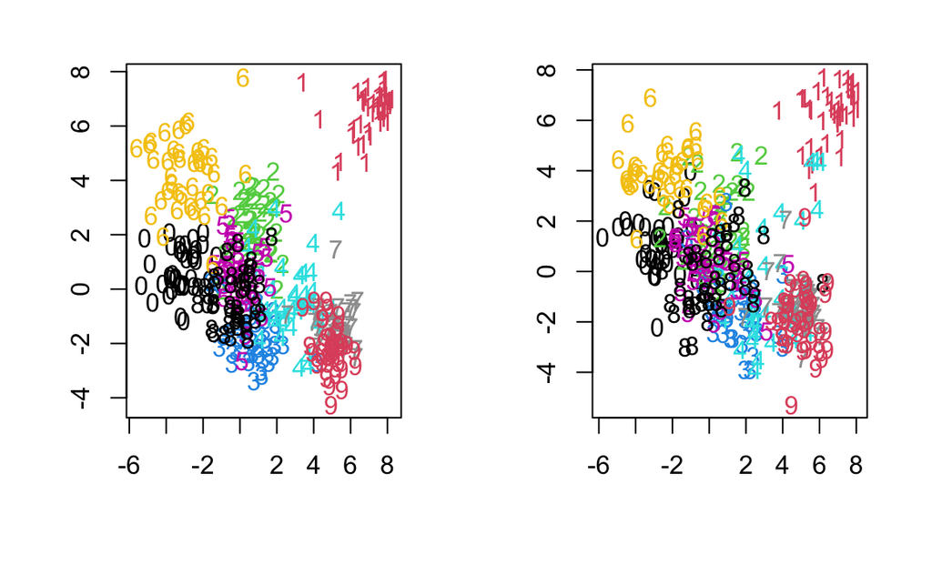

```r
plot(newFtest[,1], newFtest[,2], type="n", xlab="", ylab="")
text(newFtest[,1], newFtest[,2], Ytest, col=Ytest+1)
```